# Credit Modelling

Chris Hua

Kevin Huo

Arjun Jain

Juan Manubens

11/7/2016

forgive me

# Basic Modelling

We model “default probability” with respect to “FICO” score only. First, we note the distribution of the outcome variable:

```
.
Defaulted      Paid
     1623      8377
```

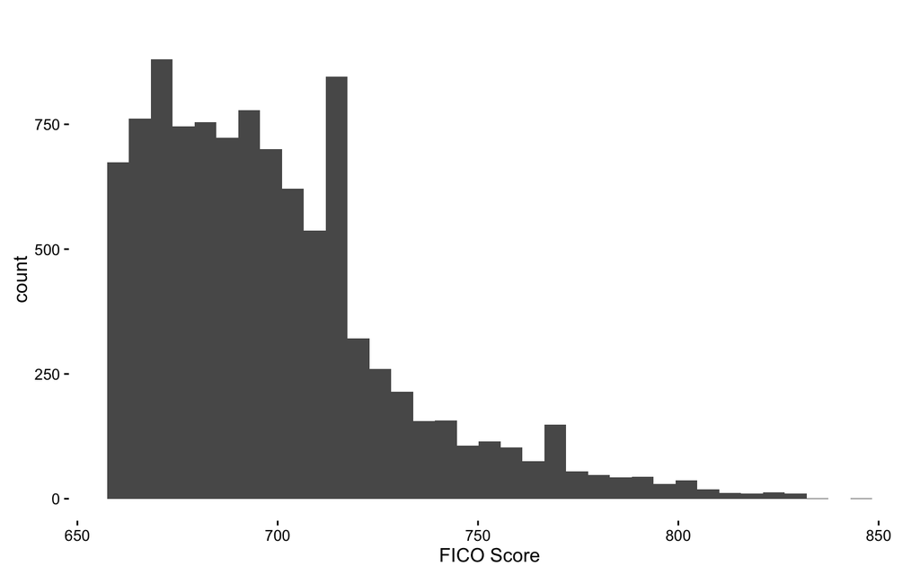

**a.** We expect a negative coefficient on FICO. Intuitively, a customer is less likely to default the better their credit score is. We would also expect a positive intercept, because for a customer with 0 credit score (the condition for the intercept), they have terrible chances of paying off the bill, and thus high chance for default.

**b.** We estimate our model using `glm` approach with a binomial prior. Summary statistics:

| term | estimate | std.error | statistic | p.value |
| --- | --- | --- | --- | --- |
| (Intercept) | -7.68 | 0.76 | -10.17 | 0 |
| fico | 0.01 | 0.00 | 12.29 | 0 |

By p-value, `fico` is a statistically significant value at better than at 0.01 level, indicating that by itself, `fico` is a useful predictor for default outcomes.

# Model Evaluation

**(a)** We can estimate a probability of default via the formula from class 4:

$$Pr(f) = \frac{\exp(\beta_0 -\beta_1 \times f)}{1 + \exp(\beta_0 - \beta_1 \times f)}$$

Since our model only includes FICO scores, we can easily plot FICO vs estimated probability of default.

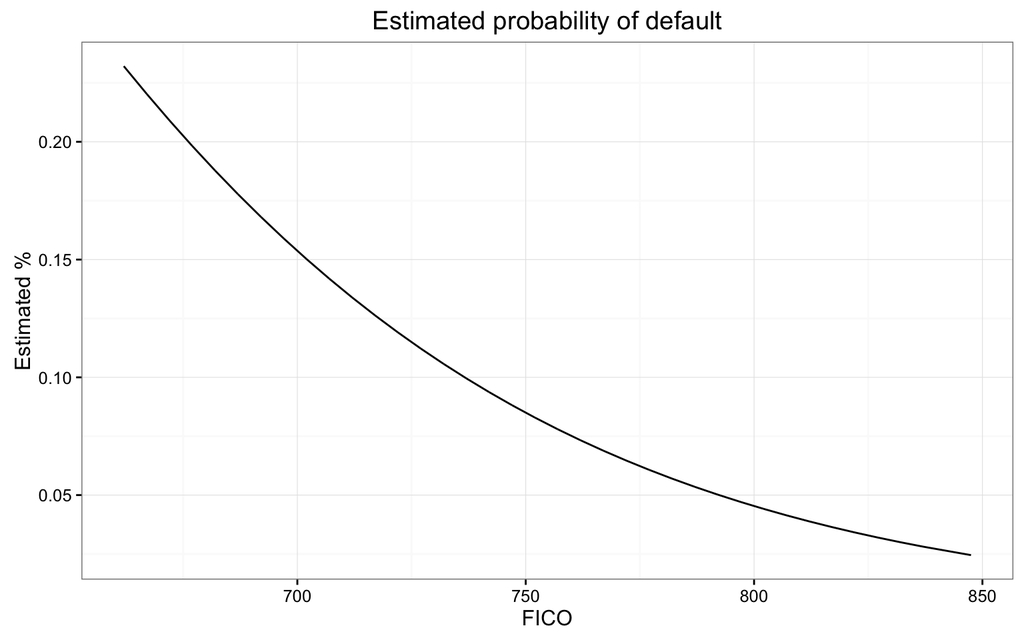

Interestingly, we can compare this plot to the empirically determined default risk. We can see that the estimated curve fits very well, except for the outliers in high credit score. This might tell us that high credit score borrowers have asymmetric information about their ability to pay off loans, and they are the ‘lemons’ in this market.

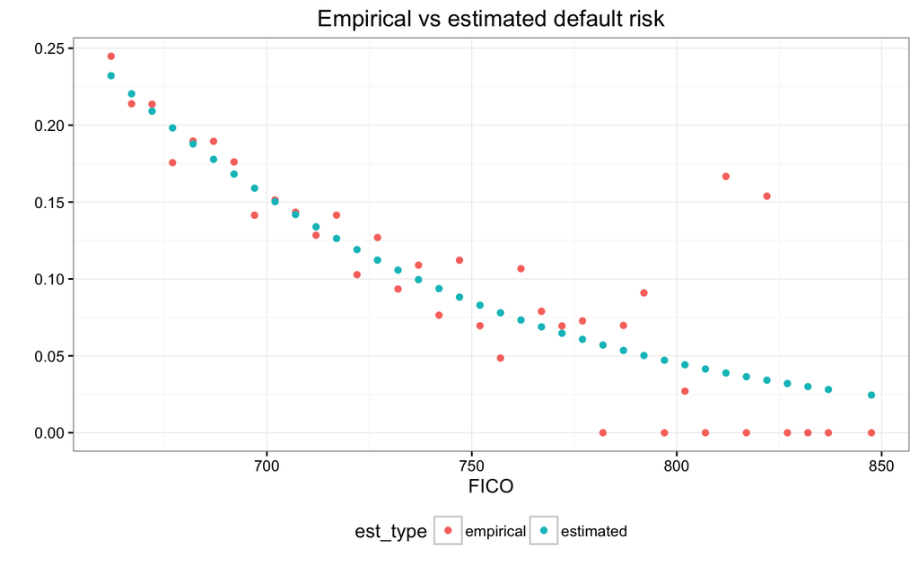

**(b)** Then, we can plot a corresponding ROC curve for this model:

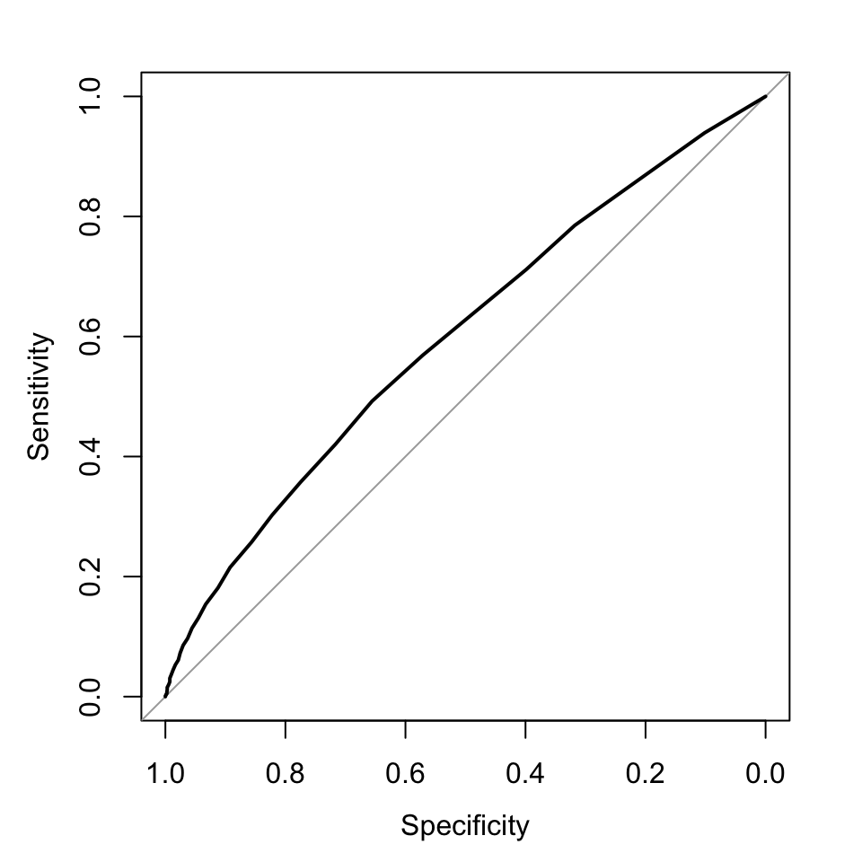

```
##
## Call:
## roc.formula(formula = default ~ prob, data = .)
##
## Data: prob in 1623 controls (default Defaulted) > 8377 cases (default Paid).
## Area under the curve: 0.5981
```

**(c)** For this model, we have AUC of 0.5981371. This is better than 0.5. It’s consistent with the findings in part 1b, where we found that FICO was a statistically significant predictor alone of default.

**(d)** This is essentially using a 0.1 threshold on our probabilities of default. Then, we can create a confusion matrix:

|  | Defaulted | Paid |
| --- | --- | --- |
| FALSE | 89 | 1095 |
| TRUE | 1534 | 7282 |

# An out-of-sample analysis

**(a)** The new model, estimated on the first 9000 rows, is given by these summary statistics:

| term | estimate | std.error | statistic | p.value |
| --- | --- | --- | --- | --- |
| (Intercept) | -7.16 | 0.79 | -9.06 | 0 |
| fico | 0.01 | 0.00 | 11.11 | 0 |

**(b)** Then, we can predict probabilities for the remaining loans, and then create an ROC curve for both fits:

```
##
## Call:
## roc.formula(formula = default ~ prob, data = .)
##
## Data: prob in 1623 controls (default Defaulted) > 8377 cases (default Paid).
## Area under the curve: 0.5981
```

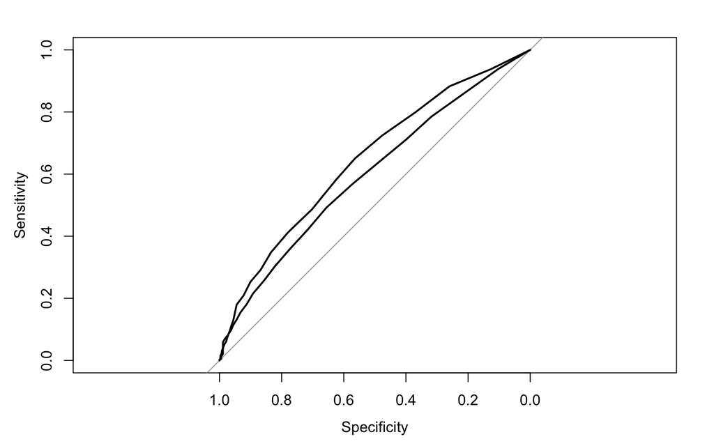

```
##
## Call:
## roc.formula(formula = default ~ pred, data = ., )
##
## Data: pred in 181 controls (default Defaulted) > 819 cases (default Paid).
## Area under the curve: 0.6459
```

**(c)** The area below the new ROC curve gets larger. We are no longer overfitting our dataset.

**(d)** Vacuously, you don’t want to use all variables available, because some of the variables are unique to a person or a loan- e.g. “id”. These could perfectly estimate somebody’s probability of default in the sample set but have no predictive use.

We fit the model and show the Anova table (type II tests):

```
## Analysis of Deviance Table (Type II tests)
##
## Response: default
##            LR Chisq Df Pr(>Chisq)
## fico         5.8760  1    0.01535 *
## int_rate     7.8866  1    0.00498 **
## emp_length   7.2645 10    0.70026
## annual_inc   9.2386  1    0.00237 **
## ---
## Signif. codes:  0 '***' 0.001 '**' 0.01 '*' 0.05 '.' 0.1 ' ' 1
```

```
## Analysis of Deviance Table (Type II tests)
##
## Response: default
##            LR Chisq Df Pr(>Chisq)
## fico         7.1142  1  0.0076476 **
## int_rate     8.2443  1  0.0040880 **
## annual_inc  11.1725  1  0.0008302 ***
## ---
## Signif. codes:  0 '***' 0.001 '**' 0.01 '*' 0.05 '.' 0.1 ' ' 1
```